# BMIp

Monica Maria Solorzano Rodriguez

12/1/2020

## The Concept

It is recommended by most clinical associations that people check their weight once or twice a year beginning at age 20 and up until 40 if they feel fine and have a normal weight. Nevertheless, if someone has a tendency to gain weight easily or is trying to loose weight, is preferable to have a scale at home in order to weigh oneself more often. Despite this, it is not recommended to do this everyday but once a week, first thing in the morning, have in mind that it needs to be a slow process.  
The BMI (body mass index) is what one needs to know to find out if one is in the right weight for the height. It is calculated by dividing weight in pounds by the squared height in inches and multiply the result by 703. A BMI between 18.5 and 24 is ideal, below 18.5 it indicates underweight and it is as much of a concern as overweight, between 25 and 30 indicates overweight, between 31 and 40 indicates obesity, and higher than 40 indicates morbid obesity. These values being presented are only valid for adults over 18 years of age.

## ui Code for BodyMassIndex App

```r
library(shiny)
shinyUI(fluidPage(
    titlePanel("Adult Body Mass Index"),
    sidebarLayout(
        sidebarPanel(
          numericInput("numeric", "Your weight in pounds:",
                       value = 120, min = 80, max = 1000, step = 1),
          sliderInput("height","Your height in inches:", min = 58,max = 76,
                        value = 58),
          checkboxInput("show_BMI", "Show/Hide BMI Indicator", value = TRUE),
          checkboxInput("show_comment", "Show/Hide Comment", value = TRUE)
        ),
        mainPanel(
          h3("BMI for 18 years and older"),
          textOutput("text1"),
          textOutput("text2"),
          textOutput("text3")
        )
    )
))
```

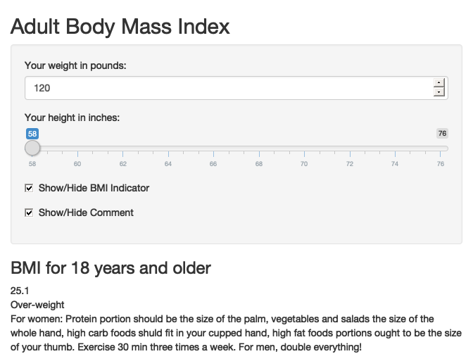